# Ein Jahr mit Krieg und Frieden - Bayerische Staatsoper

[figure not shown]

[figure not shown]

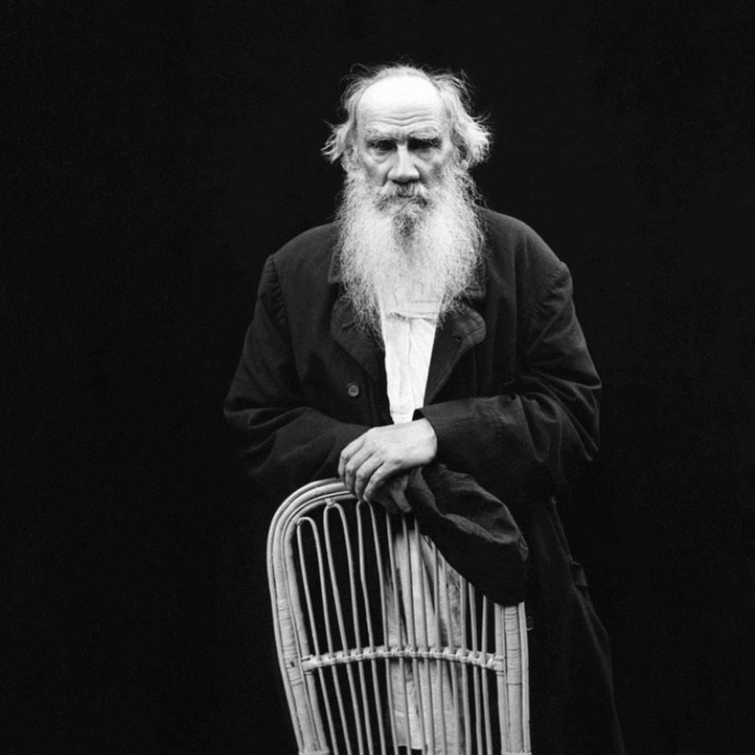

# Ein Jahr mit Krieg und Frieden

Text: Holger Noltze

*Holger Noltze ist Autor, Journalist und Fernsehmoderator im Bereich der klassischen Musik. Nach seinem Studium der Alt- und Neugermanistik sowie Hispanistik wurde er mit einer Arbeit über den Parzival-Roman Wolframs von Eschenbach promoviert und war daneben journalistisch im Bereich von Musik- und Literaturkritik in Rundfunk und Presse tätig. Seit 2005 lehrt er als Professor für Musik und Medien / Musikjournalismus an der Technischen Universität Dortmund. Zahlreiche Buchveröffentlichungen, u. a. Liebestod. Wagner, Verdi, wir (Hamburg 2013) und Die Leichtigkeitslüge. Über Musik, Medien und Komplexität (Hamburg 2010). Für die Bayerische Staatsoper gestaltet er die Audiofeatures zu allen Neuproduktionen.*

**Dicke Bücher**

Die Entscheidung, ein dickes Buch zu lesen, so tausend Seiten aufwärts, ist derjenigen zu einer langen Reise vergleichbar. Es sind gewissermaßen Ozeanüberquerungen, es geht nicht schnell, und die zwanghafte Beschleunigung des Lesetempos bringt wenig. Es liegt immer noch unüberschaubar viel vor einem, Eile gibt keinen Sinn. So kann die Entscheidung, sich einen wirklich langen Roman wie Lew Tolstois *Krieg und Frieden* vorzunehmen, neben der Sorge, ob man es denn „schaffen“ wird, auch eine kleine Euphorie auslösen: Man sticht in See, es kommt etwas Neues, es wird dauern, man wird sich in dem Riesentext verlieren und hoffentlich wiederfinden, man wird eine spürbare Strecke Lebenszeit unsichtbar begleitet von einem endlos scheinenden Erzählfaden, teilt die Aufmerksamkeit für die unabwendbaren Forderungen seines Alltags mit der für eine zweite Welt. Im Abstand zur ersten, der sich daraus ergibt, liegt ein Gewinn an Perspektive. Marcel Prousts *Recherche,* noch ein Mehrfaches länger als Tolstois Riesenschiff, verändert seine geduldige Leserschaft (die ungeduldige steigt ohnehin bald aus); wir werden trainiert in diesem mikroskopierenden Blick, sei es in Landschaften, Architekturen oder in Soziales. Das Blickvermögen aber bleibt, noch wenn die Lektüre längst abgeschlossen ist, und es ist mehr als bloß ein Nachbild, das verklingen wird. Die Dauer, mit der Prousts oder Tolstois oder Cervantes’ Wortströme durch unser Hirn laufen, ist schon für sich ein Teil ihrer Überzeugungskraft (so wie in Richard Wagners Musikdramen: es geht nicht kürzer), und bleiben nachhaltig wirksam. Darin liegt das große Versprechen dicker Bücher, und es ist das glatte Gegenteil von „Zeitvertreib“. Die schiere Länge sorgt nebenbei auch dafür, dass der schnöde Bildungsimperativ „musst du kennen“/ „muss man gelesen haben“ keine Rolle mehr spielt, spätestens nach hundert Stunden. Es steht nicht dafür.

**Anfangen**

Zehn Jahre nach *Woina i mir (Krieg und Frieden),* erschienen 1868/1869, schreibt Tolstoi seinen anderen großen Roman, *Anna Karenina,* und beginnt ihn mit einem der berühmtesten Sätze der Weltliteratur: „Alle glücklichen Familien sind einander ähnlich; jede unglückliche Familie hingegen ist auf ihre besondere Weise unglücklich.“ Der Satz ist genial, brauchbar als Aphorismus und vor allem die denkbar beste Eröffnung und Einstimmung auf das, was kommt. Mit ein paar Worten und der schlichten, vom Semikolon sanft markierten Unterscheidung eben glücklicher oder unglücklicher Familien hebt er den Lesenden auf eine Art Hochsitz der Betrachtung. So schauen wir in die Welt wie auf ein Wimmelbild, die unendlichen Verstrickungen jener für Tolstoi so zentralen sozialen Maßeinheit der Familie. Das Bild teilt sich in die Glücklichen und die Unglücklichen; das funktioniert, gegen jedes Erfahrungswissen, dass dem so nicht sein kann, schon, weil doch in jedem Glück auch ein Unglück west, und hoffentlich auch umgekehrt. Der offensichtlich gewagte Satz funktioniert also über den Reiz der Vereinfachung, zugleich macht er Leserin und Leser mit sechzehn Worten zu Komplizen des Erzählers und spannt die Erwartung, alles nun Folgende habe sich als Entfaltung und Konkretisierung dieses kühnen Gedankens zu bewähren.

Und wie beginnt *Krieg und Frieden?* – „‚Eh bien, mon prince: Gênes et Lucques ne sont plus que des apanages, des Landgüter, de la famille Buonaparte.‘“ Es geht noch acht Zeilen französisch weiter, bevor wir wissen dürfen, wer spricht: „Mit diesen Worten empfing im Juli 1805 die bekannte Anna Pawlowna Scherer, Hofdame und Vertraute der Kaiserin Marija Fjodorowna, den einflussreichen ranghohen Fürsten Wassili, der als erster auf ihrer Abendgesellschaft erschien.“ *–* Statt vom Hochsitz allgemeiner Betrachtung werden wir hier in eine uns eben nicht bekannte Abendgesellschaft katapultiert, kennen die Gastgeberin eben nicht (und werden sie auch viele Seiten später kaum kennenlernen), dem „einflussreichen ranghohen“ Fürsten Wassili werden wir als Vater des vergnügungssüchtigen, liebespolitisch komplizierten, skrupellosen Anatol und der schönen, oberflächlichen Hélène, der dann späteren Gräfin Besuchowa, begegnen. Doch wird die Handlung gar nicht sehr um die Kuragins des Fürsten Wassili kreisen, sondern um die Bolkonskis (Andrej), die Besuchows (Pierre) und die Rostows (Natascha, Nikolai).

Das alles wissen wir Leser der ersten Seite nicht, oder wissen es nur ungefähr aus dem Kino. Zwar fällt in der zweiten Zeile das historische Signalwort „Buonaparte“, aber was es hier mit Genua und Lucca auf sich hat, mit den oberitalienischen Eroberungen des von der russischen Hofdame zum „Antichrist“ ernannten französischen Feldherrn, man weiß es einstweilen nicht. Lange fremdsprachige Zitate, nicht selbsterklärende politische Anspielungen, zunächst unklares Personal: Tolstoi macht es seinem Publikum, anders als im Fall *Anna Karenina,* hier eben nicht leicht, sondern schwer. Aber auch das ist ein Kunstgriff, eine Vorbereitung auf das, was auf uns zukommt: Es wird noch viel Französisch folgen, allerhand historische Details eines schon zum Zeitpunkt des Schreibens mehr als fünfzig Jahre zurückliegenden Krieges werden vorausgesetzt, und auch der aufmerksame Leser, die genaue Leserin wird immer wieder zum Personenverzeichnis am Ende hin- und zurückblättern müssen. Dort finden sich dann auch all die Namensformen der Hauptfiguren, was nun keine Tolstoi’sche, sondern eine russische Spezialität ist. Pierre wird, je nachdem, eben auch Petruscha genannt, oder Pjotr Kirillowitsch, der junge Besuchow und so weiter. All das klare Verstöße gegen das „KISS“-Mantra des Populären: „Keep it short and simple“ – von wegen …

> Man kann dem so geschichtsversessenen wie geschichtsvergessenen russischen Präsidenten die Lektüre des russischen Klassikers *Krieg und Frieden* nur dringend empfehlen, die Geschichte eines überfallenen Landes und des katastrophalen Rückzugs der Invasoren. Bis zum Ende.

**On parle français,**

vor allem im ersten, dem „Friedens-Teil“. Gutes Französisch ist der Code der gehobenen Gesellschaft von Moskau und Petersburg, und die Absurdität, dass damit die Sprache des Feindes gesprochen wird, sollen wir, so will es der Erzähler, wieder und wieder spüren, wenn der Lesefluss durch die Fremdsprachigkeit gebremst wird. Es wird schließlich eine Welt im Untergang gezeigt, dazu gehören ihre Fassaden. Wir werden sie, nicht erst, wenn Moskau brennt, bröckeln sehen. Und Napoleon erscheint hier durchaus nicht überwiegend als der „Antichrist“, sondern als Genie und Faszinosum. Seine Demontage, als größenwahnsinniger Poser, geschieht dann aber gründlich.

**Familiengeschichten**

Es geht natürlich um alles, um Krieg und Frieden eben, am Ende schreibt der große Tolstoi seine geschichtsphilosophischen Ideen ganz unverschlüsselt auf. Doch im Kern erzählt er Familiengeschichten, und im Innersten der vielschichtigen sozialen Zwiebel sind das die Geschichten der Bolkonskis und der Rostows. Er soll sie ein wenig bei den eigenen Großeltern und der Familie seiner Frau abgeschrieben haben. Haupt der Bolkonskis ist der „alte Fürst“, Nikolai Andrejewitsch, wegen seiner knorrigen Strenge auch „König von Preußen“ genannt. Dann Prinzessin Marja, die keine Schönheit ist, aber mit strahlenden Augen bezaubern kann; am Ende wird Nikolai Rostow sie doch heiraten. Ihr Bruder Andrej geht einen langen Weg von der Bewunderung Napoleons zum glühenden Kämpfer fürs russische Vaterland; bei der zentralen Schlacht von Borodino wird er schwer verletzt. Andrej ist, nach dem Tod seiner Gattin Lisa, der „kleinen Fürstin“, mit Natascha, der jüngeren Tochter der Rostows, zwischenzeitlich verlobt, am Ende begleitet sie sein langes Sterben und wird schließlich Pierres zweite Frau. Pierre ist als unehelicher Sohn des Grafen Besuchow unermesslich reich; die Rostows dagegen verarmt, der alte Graf Rostow trägt es mit Jovialität; zum Haus gehören neben der alten Gräfin Rostowa und der temperamentvoll anmutigen Natascha noch ihre ältere, kühle Schwester Vera und Nikolai, der zu Beginn des Romans sein Studium aufgibt, um zu den Husaren zu gehen. Außerdem Sonja, Nichte und Ziehtochter der Rostows, verliebt in und verlobt mit Nikolai, bis sie zugunsten Marja Bolkonskajas entsagt, und der jüngste, Petja, der unbedingt auch zu den Soldaten will und in einem sinnlosen Partisanenangriff auf die bereits zurückweichenden Franzosen tödlich verwundet wird.

Vielfädig verwoben also vor allem die Familien Bolkonski und Rostow, lesend begleiten wir sie, wo Familie sich manifestiert, auf Feste und in Salons, ins Theater, bei ländlichen Jagden, Geburten und Todesfällen. Dazu kommt Pierre, der linkische, etwas dickliche, bald steinreiche Freund Andrejs als weitere Hauptfigur. Andrej und Pierre: beide ernsthafte Sinnsucher in Zeiten des Krieges, der eine kämpfend, der andere verzweifelt beobachtend, Möchtegern-Attentäter Napoleons, und beide, so oder so, verwundet.

> Zu den Werten, die wir Putins Staatsterrorismus entgegenhalten, gehört die Freiheit des Denkens und die Freiheit, zu sagen, was man denkt – und selbstverständlich mit einem Echo darauf zu rechnen. Das ist Diskurs.

**Krieg**

Zufall. Meine Lektüre von *Krieg und Frieden* begann, bevor der neue Krieg uns so nah kam. Als Putins Armee die Ukraine überfiel, war ich gerade beim Einzug der Franzosen in das unwirklich verlassene Moskau und mochte für ein paar Wochen nicht weiterlesen, die aktuellen Bilder nicht mit dem hundertfünfzig Jahre alten Roman über Napoleons Russlandfeldzug vor mehr als zweihundert Jahren überblenden. Bald aber las ich weiter, fasziniert von Tolstois tiefer Mikroskopie seiner Figuren wie von der Riesenarchitektur des Ganzen. Es fällt gerade auf, wie viel russische Literatur, wie viel russische Musik in uns steckt und selbstverständlich umgibt, so viel Wichtiges von Tschaikowski, Strawinsky, Prokofjew, Schostakowitsch, Rachmaninow. Auch wenn ich verstehen kann, dass Menschen aus der Ukraine das jetzt anders sehen: Tatsächlich keinen Moment käme mir in den Sinn, diese große russische Kunst, die oft genug nicht ohne das Leiden ihrer Schöpfer an russischer Politik zu verstehen ist, das alles nicht mehr hören zu wollen oder zu können, aus Aversion gegen ein „Russisches“, auf das sich Putin empörenderweise beruft. Dass er dem Westen das „Canceln“ russischer Kultur vorwirft, ist doppelt unerhört, denn, nach einer Schrecksekunde hier und da, wurde auch im westlichen Musikbetrieb klar, dass Putins Politik mit Tolstoi und Tschaikowski nicht nur nichts zu tun hat, sondern die Perversion darin liegt, dass ausgerechnet er glaubt, sich auf „russische Kultur“ berufen zu dürfen. Das alles ist nicht neu, natürlich nicht, wir kennen ja die Indienstnahme etwa Beethovens für das, was in Hitlers Reich als „deutsche Kultur“ in Stellung gebracht wurde.

Zu den Werten, die wir Putins Staatsterrorismus entgegenhalten, gehört die Freiheit des Denkens und die Freiheit, zu sagen, was man denkt – und selbstverständlich mit einem Echo darauf zu rechnen. Das ist Diskurs. Dazu gehört auch das gute Zuhören, die Aufmerksamkeit für die vielen Töne zwischen Schwarz und Weiß. Man kann dem so geschichtsversessenen wie geschichtsvergessenen russischen Präsidenten die Lektüre des russischen Klassikers *Krieg und Frieden* nur dringend empfehlen, die Geschichte eines überfallenen Landes und des katastrophalen Rückzugs der Invasoren. Bis zum Ende.

**Frieden**

Dieses große Buch zerfällt, wie man so sagt, in mindestens zwei Teile. Weil der zweite den Krieg ins Zentrum des Geschehens rückt, die schnellen Erfolge Napoleons bis zur Einnahme Moskaus, die nicht zum Triumph geraten will, dann die Wendung der Dinge, der Rückzug der Franzosen und so weiter, mag man die früheren Kapitel als „Friedens-Teil“ lesen. Was allerdings darüber täuscht, dass von Anfang an, schon bei der Abendgesellschaft der Anna Pawlowna Scherer, vom Krieg geredet, ja geplaudert wird. Es ist kein Frieden, sondern Vor-Krieg, aber was Tolstoi (für uns heute) haarsträubend eindrücklich gelingt, ist die Darstellung des schleichenden Übergangs von „Frieden“ zu Krieg, die Verwandlung des Themas vom interessanten Gesprächsgegenstand der Salons zu etwas Existenziellem. Vom Parlando, vom Spiel der Meinungen, Einschätzungen, Ideologien zu den Wahrheiten der Schrecken des Krieges: ein Wunder, wie Tolstoi das alles auf seine Riesenleinwand bekommen konnte. Es konnte gelingen, weil er souverän auf eine Zentralperspektive verzichtete. In der Salonsphäre regiert subtile Ironie, für das Geschehen der Schlachtfelder, erst aus der Ferne, dann immer näherkommend, verlangte es eine andere Optik. So schildert er etwa die Schlacht von Borodino aus der staunenden, taumelnden Sicht des zivilen Brillenträgers Pierre, oder den legendären improvisierten Militärrat in einer Bauernhütte bei Fili aus der eines sechsjährigen Mädchens, die den Diskussionen der Generäle von der Ofenbank aus folgt. Soll „Russlands alte heilige Hauptstadt!“ ohne weitere Kämpfe dem Feind überlassen werden? Was versteht eine Sechsjährige davon? „Malascha, die schon längst zum Abendessen erwartet wurde, ließ sich vorsichtig rückwärts von ihrer Pritsche herab, stemmte dabei ihre kleinen nackten Füße gegen die Abstufungen des Ofens, wand sich zwischen den Beinen der Generäle durch und huschte zur Tür hinaus.“ – Von der großen Geschichte ist nur im Spiegel kleiner Menschen ein Hauch zu erfassen: Absage an die Feldherrnperspektive.

> Was ist Macht? Macht ist die Gesamtheit der Willen, übertragen auf eine Person.

**Kutusow**

Ätzend der Spott, der das eingebildete Genie Napoleon trifft, der von seinen Aussichtsposten aus wichtig durch Fernrohre schaut, aber eigentlich nichts sieht; dessen weltgeschichtliche Entscheidungen aus Pseudotheorien oder irgendwie aus dem Bauch kommen, manchmal und zunächst zum Erfolg führen, nach der Einnahme und dem Brand Moskaus dann aber nicht mehr. Sieg oder Niederlage hängen von so vielen und so winzigen und für sich unbedeutenden Faktoren ab, die, letztlich undurchschaubar, eine Art psychologisch-militärischer Resultante bilden und zum bestimmenden Faktor werden, so dass deren Berechnung eben nicht möglich ist. Militär- und Kriegstheorie gewinnt ihre Erkenntnisse aus der Rückschau, deshalb liegt sie im Nachhinein immer richtig, doch bei der Einschätzung der Gegenwart muss sie versagen. In der eigenen Ofenbankperspektive seiner Mitschrift der historischen Ereignisse um das Jahr 1812 ist das alles für den Erzähler bloß gewaltige Besserwisserei.

Man kann *Krieg und Frieden* auch als ein großes De-Heroisierungs-Programm lesen. In der Bauernstube von Fili geht es ja um eine wirkliche Entscheidung: Moskau aufgeben? Undenkbar für die russisch-patriotischen Superexperten. Kutusow, *Großväterchen* Oberkommandierender, hört sich alles an. Wartet ab. Seufzt. „‚Eh bien, messieurs! Je vois que c’est moi qui payerai les pots cassés‘,sagte er [Ich sehe schon, dass ich es bin, der für das zerbrochene Geschirr wird zahlen müssen]. Er erhob sich langsam und trat an den Tisch. ‚Meine Herren, ich habe Ihre Meinungen gehört. Einige werden mir nicht zustimmen. Doch ich‘ (er hielt inne) ‚gebe mit der Befehlsgewalt, die mir von meinem Kaiser und dem Vaterland übertragen worden ist, ich – gebe den Befehl zum Rückzug.‘“

Es ist die, wie sich zeigen wird, richtige Entscheidung. Der Vormarsch der Franzosen läuft ins Leere, kleine Fehler der Invasoren summieren sich, der Winter kommt, der französische Rückzug gerät zur Flucht, zur Katastrophe. Generalfeldmarschall Kutusow, den sie den „Durchlauchtigsten“ nennen und der bei wichtigen Stabsgesprächen einschläft, der warten kann, demütig gegenüber einer Vorsehung, der wir nicht in die Karten schauen können, der gegen die allgemeine Stimmung entscheidet und weiß, „*que c’est moi qui payerai les pots cassés“,* – er siegt als Anti-Held, getragen von der Liebe seines Erzählers. Man kann das sehr „russisch“ finden.

**Macht**

„Was ist die Ursache historischer Ereignisse? Die Macht. Was ist Macht? Macht ist die Gesamtheit der Willen, übertragen auf eine Person. Unter welchen Bedingungen werden die Willen der Massen auf eine einzige Person übertragen? Unter den Bedingungen, dass diese Person Ausdruck des Willens aller Menschen ist.“

Die Frage, welche Kräfte bestimmen, was wir, aus dem rückschauenden Abstand, „Geschichte“ nennen, die große also, aber auch die privaten, „kleinen“ Geschichten, treibt den Erzähler um. Auch wenn sich auf der Vorderbühne Historisches ereignet und abgebildet wird: Im Hintergrund, in Exkursen, die immer länger werden, wird nachgedacht: Was ist der Sinn? Warum geschieht, was geschieht, wenn man ganz genau hinschaut? Sind es die genialen Eingebungen der Feldherren und mutmaßlichen Weltgeschichtslenker? Ist es, was Kutusow den „Geist der Truppe“ nennt? So landet Tolstoi, immer weniger Historienmaler, der getreulich bunt auspinselt, wie es gewesen sein könnte, immer mehr Geschichtsphilosoph, immer tiefer bohrend, bei der Frage nach der Macht als zentralem Movens. Und alle Verstehensbemühung endet in einem Zirkelschluss: „Das heißt, Macht ist Macht. Das heißt, Macht ist ein Wort, dessen Bedeutung wir nicht verstehen.“

Das ist, nach zweitausend Seiten, ein erschütterndes Eingeständnis. Und es auszusprechen von einiger Größe.

**Hollywood. Prokofjew**

Am schwersten ist es mit Audrey Hepburn. An dieser charmant kindsköpfig verdrehten Natascha kann man kaum vorbeisehen, selbst noch mit dem Buch in der Hand und fern von Fernsehen oder Kino. Als ob Tolstoi seine weibliche Lieblingserfindung in dieser amerikanischen Verkörperung vorausgeahnt hätte. King Vidors Cinemascope-Version des Romans kam 1956 auf die Leinwände der Welt, gedreht in Cinecittà und an anderen Orten in Italien, mit zehntausend Statisten für die Breitleinwandschlachten und reichlich Starpower. Doch noch als Dreieinhalbstunden-Kino-Epos mit eigener Ambition, ein Klassiker zu sein, kommt einem Tolstois Opus magnum hier reichlich geschrumpft vor.

Das dicke Buch hat übrigens keine Genrebezeichnung, wir nennen es nur aus Gewohnheit einen Roman, gegen den Willen des Autors. Als Sergej Prokofjew 1941 zusammen mit seiner Frau Mira Mendelson daraus ein Libretto zu kompilieren beginnt, geschieht es unter dem Eindruck des deutschen Überfalls, komponiert als Oper, was an Tolstois Buch auch Oper ist, endet aber nicht mit der bemerkenswert leisen Nicht-Auflösung des Buchs (vor seinem langen Epilog), mit Pierres und Nataschas Fahrt nach Petersburg und dem schönen Schlusswort der gereiften Natascha an ihre Schwägerin Marja: „Nein, nein, es muss so sein … Ja, Marie? Es muss so sein.“ Für Prokofjew 1941 musste es anders sein, ein Sieg-Finale mit Kutusow und jubelndem Volk. Habent sua fata libelli, heißt es, Bücher haben ihre Geschichte, und dieses zumal.

# Krieg und Frieden (Woina i mir)

# Hintergründe zum Stück

[interactive chart not shown]